# ISA 616 Analytics Workflow - Regression Model to Predict Wine Quality for Wine Inc.

Ethan Rosser

10/02/2020

# Overview of Analysis

In this analysis, I create a stepwise multiple linear regression model that uses physiochemical properties of wine to predict the wine quality score. This model will allow the product design team at Wine Inc. that creates new wine variants to better understand what levels of physiochemical properties lead to a better wine quality score for their variants of the Portuguese “Vinho Verde” wine. This regression model will help Wine Inc.’s product design team to produce higher quality wine and has the potential to increase sales revenue and improve brand reputation. This analysis may also help to decrease costs associated with creating new types of wine. This is because the product design team within the company will have a statistically supported understanding of how each physiochemical property of wine impacts the quality score and may be able to avoid producing low quality wine.

For this analysis, we use R version 3.6.1. Further detail regarding the session information and packages used can be seen in the appendix section. Be sure to have the correct version of R and packages installed or there may be issues with reproducibility.

```r
# Install pacman if it is not already installed
if (!require("pacman")) install.packages("pacman")
# Load in necessary packages
pacman::p_load(DataExplorer, corrplot, curl, caret, dplyr)
```

# Data Description

I have accessed wine quality data from the University of California, Irvine’s Machine Learning Repository. There are two datasets related to red and white variants of the Portuguese “Vinho Verde” wine. One dataset is for the white variants, and one is for the red variants. We access these datasets directly via the curl package, but the link to manually download these two datasets is below in case there are any issues: https://archive.ics.uci.edu/ml/datasets/wine+quality

Before performing exploratory analysis, we first must combine the 2 datasets into 1. This is done by adding a “Color” variable on each dataset and then rbinding the datasets together.

```r
# Read in 2 datasets. 1 dataset is for white wine and the other dataset is for red wine.
white <- read.csv(curl("https://archive.ics.uci.edu/ml/machine-learning-databases/wine-quality/winequality-white.csv"), sep = ";")

red <- read.csv(curl("https://archive.ics.uci.edu/ml/machine-learning-databases/wine-quality/winequality-red.csv"), sep = ";")

# Create a column to specify the color of the wine for both datasets.
white$Color <- "White"
red$Color <- "Red"

# Combine the red and white datasets together
wine <- white
wine <- rbind(wine, red)

# Change the data type for the Color variable to be a factor
wine$Color <- as.factor(wine$Color)
```

We can now properly describe the dataset. In our dataset, there are 6497 total observations of 13 variables. We have 12 numeric variables and 1 factor variable (Color) that has 2 categories: red and white.

```r
# Show the structure of the data set
str(wine)
```

```
## 'data.frame':    6497 obs. of  13 variables:
##  $ fixed.acidity       : num  7 6.3 8.1 7.2 7.2 8.1 6.2 7 6.3 8.1 ...
##  $ volatile.acidity    : num  0.27 0.3 0.28 0.23 0.23 0.28 0.32 0.27 0.3 0.22 ...
##  $ citric.acid         : num  0.36 0.34 0.4 0.32 0.32 0.4 0.16 0.36 0.34 0.43 ...
##  $ residual.sugar      : num  20.7 1.6 6.9 8.5 8.5 6.9 7 20.7 1.6 1.5 ...
##  $ chlorides           : num  0.045 0.049 0.05 0.058 0.058 0.05 0.045 0.045 0.049 0.044 ...
##  $ free.sulfur.dioxide : num  45 14 30 47 47 30 30 45 14 28 ...
##  $ total.sulfur.dioxide: num  170 132 97 186 186 97 136 170 132 129 ...
##  $ density             : num  1.001 0.994 0.995 0.996 0.996 ...
##  $ pH                  : num  3 3.3 3.26 3.19 3.19 3.26 3.18 3 3.3 3.22 ...
##  $ sulphates           : num  0.45 0.49 0.44 0.4 0.4 0.44 0.47 0.45 0.49 0.45 ...
##  $ alcohol             : num  8.8 9.5 10.1 9.9 9.9 10.1 9.6 8.8 9.5 11 ...
##  $ quality             : int  6 6 6 6 6 6 6 6 6 6 ...
##  $ Color               : Factor w/ 2 levels "Red","White": 2 2 2 2 2 2 2 2 2 2 ...
```

```r
head(wine)
```

```
##   fixed.acidity volatile.acidity citric.acid residual.sugar chlorides
## 1           7.0             0.27        0.36           20.7     0.045
## 2           6.3             0.30        0.34            1.6     0.049
## 3           8.1             0.28        0.40            6.9     0.050
## 4           7.2             0.23        0.32            8.5     0.058
## 5           7.2             0.23        0.32            8.5     0.058
## 6           8.1             0.28        0.40            6.9     0.050
##   free.sulfur.dioxide total.sulfur.dioxide density   pH sulphates alcohol
## 1                  45                  170  1.0010 3.00      0.45     8.8
## 2                  14                  132  0.9940 3.30      0.49     9.5
## 3                  30                   97  0.9951 3.26      0.44    10.1
## 4                  47                  186  0.9956 3.19      0.40     9.9
## 5                  47                  186  0.9956 3.19      0.40     9.9
## 6                  30                   97  0.9951 3.26      0.44    10.1
##   quality Color
## 1       6 White
## 2       6 White
## 3       6 White
## 4       6 White
## 5       6 White
## 6       6 White
```

```r
tail(wine)
```

```
##      fixed.acidity volatile.acidity citric.acid residual.sugar chlorides
## 6492           6.8            0.620        0.08            1.9     0.068
## 6493           6.2            0.600        0.08            2.0     0.090
## 6494           5.9            0.550        0.10            2.2     0.062
## 6495           6.3            0.510        0.13            2.3     0.076
## 6496           5.9            0.645        0.12            2.0     0.075
## 6497           6.0            0.310        0.47            3.6     0.067
##      free.sulfur.dioxide total.sulfur.dioxide density   pH sulphates
## 6492                  28                   38 0.99651 3.42      0.82
## 6493                  32                   44 0.99490 3.45      0.58
## 6494                  39                   51 0.99512 3.52      0.76
## 6495                  29                   40 0.99574 3.42      0.75
## 6496                  32                   44 0.99547 3.57      0.71
## 6497                  18                   42 0.99549 3.39      0.66
##      alcohol quality Color
## 6492     9.5       6   Red
## 6493    10.5       5   Red
## 6494    11.2       6   Red
## 6495    11.0       6   Red
## 6496    10.2       5   Red
## 6497    11.0       6   Red
```

This bar chart shows the frequency of red and white wines within the data. There are 4898 observations of white wine and 1599 observations for red wine.

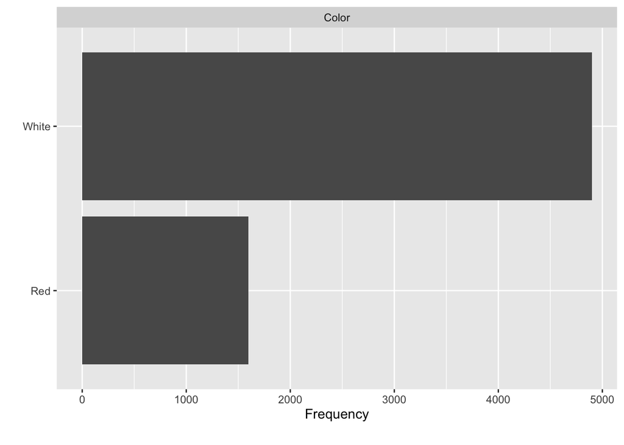

```r
# Plot bar charts to show the amount of data in each category for the categorical variables
plot_bar(wine)
```

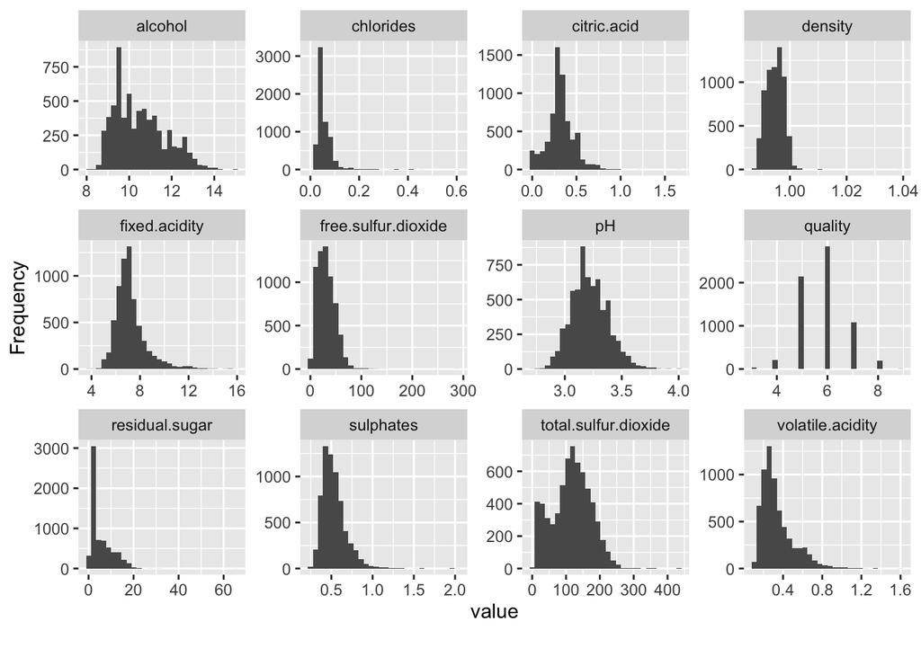

```r
# Plot histograms for the numeric variables
plot_histogram(wine)
```

There are 0 missing values in the dataset. This means that we will not have too much data pre-processing to perform before modeling.

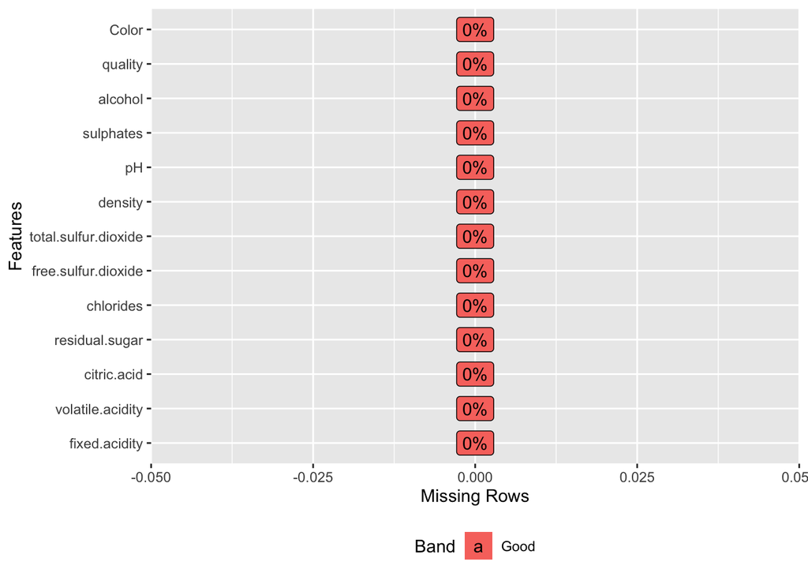

```r
# Plot the number of missing values for each variable
plot_missing(wine)
```

Here is a plot that shows the correlation between the numeric variables within the dataset. Overall, none of the variables have high enough of a correlation to be particularly concerning. But, we should make a note of the .72 correlation between total sulfur dioxide and free sulfur dioxide. Additionally, we should note the -.69 correlation between alcohol and density. But, neither of these correlations are high enough to suggest major redunancy in the variables, so we will keep all of the predictors for modeling. Another reason we should keep these variables is because we do not have too many variables in our dataset, so dimension reduction is not a huge priority.

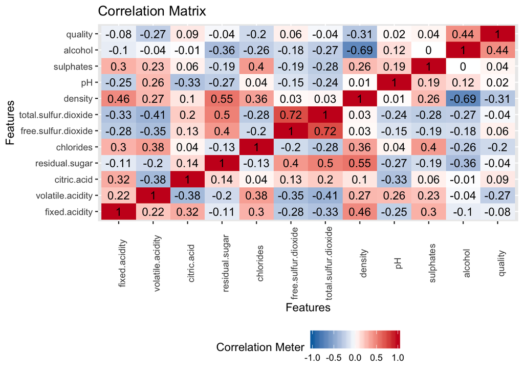

```r
# Subset the data down to just the numeric variables
numericVars <- subset(wine, select = -c(Color))
# Create a correlation matrix
plot_correlation(numericVars, title = "Correlation Matrix")
```

# Preprocessing

The main preprocessing that needs to be done for this analysis is eliminating outliers from the numeric variables. We do not need to perform any imputations due to there being no missing values.

```r
# Remove the 2 outliers with very high chloride levels
wine <- wine[ which(wine$chlorides <= .4),]

# Remove the 2 outliers with very high citric acid levels
wine <- wine[ which(wine$citric.acid <= 1),]

# Remove the 1 outlier with a high density level
wine <- wine[ which(wine$density < 1.02),]

# Remove the 1 outlier with a very high free sulfur dioxide level that was over 100 points higher than the second highest value
wine <- wine[ which(wine$free.sulfur.dioxide <= 150),]

# Remove the 3 outliers with high sulphate levels
wine <- wine[ which(wine$sulphates <= 1.7),]

# Remove the 1 outlier with a high volatile acidity level
wine <- wine[ which(wine$volatile.acidity < 1.4),]
```

We also scale the data due to the fact that many of the numeric variables within the dataset have different scales. This will also help the model to be more interpretable.

```r
# Scale every numeric variable within the dataset
wine <- wine %>% mutate_if(is.numeric, scale)
```

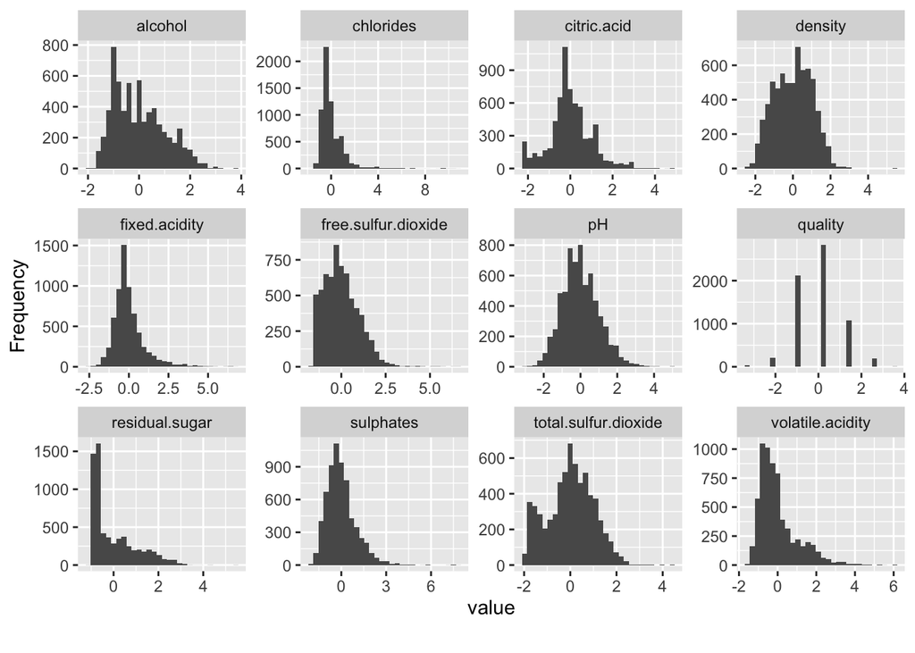

```r
# Plot histograms for the numeric variables
plot_histogram(wine)
```

# Modeling

Before modeling, we randomly split our data into training and testing datasets. We use 70% of the observations to train the model and 30% of the observations to test the model performance on data that the model was not trained on. I chose to train the model on only 70% of the data because the dataset is relatively small at roughly 6500 observations, so it is important to leave a large enough portion of the observations to test the model on. We do this splitting so that we can more effectively evaluate model performance.

```r
# Set sample size to be 70% of the total data
sampleSize <- .70 * nrow(wine)

## set the seed to make the partition reproducible
set.seed(100)

# Generate the random indexes that will be used for the training dataset
train_ind <- sample(seq_len(nrow(wine)), size = sampleSize)

# Create training and testing datasets
train <- wine[train_ind, ]
test <- wine[-train_ind, ]
```

Now that we have the data split into training and testing datasets, we can build a stepwise mutiple linear regression model. The results of this model can be seen below. Forwards and Backwards selection techniques were also attempted but did not provide as much predictive power.

```r
# Create null and full models on the training data
null = lm(quality ~ 1, data = train)
full = lm(quality ~ ., data = train)

# Build a stepwise mutiple linear regression model
stepwise = step(null, scope = list(lower = null, upper = full), direction = "both", trace = 0, k = 2)

# Show the accuracy of the model on the training data
summary(stepwise)
```

```
##
## Call:
## lm(formula = quality ~ alcohol + volatile.acidity + sulphates +
##     residual.sugar + Color + density + free.sulfur.dioxide +
##     total.sulfur.dioxide + chlorides + fixed.acidity + pH, data = train)
##
## Residuals:
##     Min      1Q  Median      3Q     Max
## -4.0493 -0.5404 -0.0473  0.5140  3.4921
##
## Coefficients:
##                      Estimate Std. Error t value Pr(>|t|)
## (Intercept)           0.34056    0.06218   5.477 4.56e-08 ***
## alcohol               0.30600    0.03247   9.425  < 2e-16 ***
## volatile.acidity     -0.27889    0.01712 -16.294  < 2e-16 ***
## sulphates             0.12126    0.01564   7.755 1.08e-14 ***
## residual.sugar        0.32614    0.04100   7.955 2.24e-15 ***
## ColorWhite           -0.45287    0.08058  -5.620 2.02e-08 ***
## density              -0.34749    0.06497  -5.348 9.32e-08 ***
## free.sulfur.dioxide   0.09911    0.01880   5.270 1.42e-07 ***
## total.sulfur.dioxide -0.07583    0.02520  -3.010 0.002630 **
## chlorides            -0.02786    0.01609  -1.732 0.083318 .
## fixed.acidity         0.11088    0.02887   3.841 0.000124 ***
## pH                    0.07624    0.02050   3.718 0.000203 ***
## ---
## Signif. codes:  0 '***' 0.001 '**' 0.01 '*' 0.05 '.' 0.1 ' ' 1
##
## Residual standard error: 0.839 on 4521 degrees of freedom
## Multiple R-squared:  0.296,  Adjusted R-squared:  0.2943
## F-statistic: 172.8 on 11 and 4521 DF,  p-value: < 2.2e-16
```

We have built our model using the training data, so we can now evaluate it using our testing data.

The Root Mean Squared Error of our model on the test data is .838

```r
# Predict the wine quality scores for the test data
testPred <- predict(stepwise, newdata = test)
# Calculate the RMSE
RMSE(testPred, test$quality)
```

```
## [1] 0.8376851
```

The R Squared vaule for our model on the test data is .302. This means that 30.2% of the variation in the wine quality score is explained by the model for the testing data.

```r
# Calculate the R Squared value
R2(testPred, test$quality)
```

```
##          [,1]
## [1,] 0.302178
```

# Conclusion

# Appendix

This output shows the session information such as the R version and the version of each of the packages used for the analysis.

[session information not shown]